# Bioetika (júlový turnus)

Zpět na rozcestník zpětné vazby | Tento report we Wordu | Data v CSV

## Hodnocení kurzu

Průměrná známka:

| Blok setkání | Průměrná známka |
| --- | --- |
| B | 1.17 |

### Hodnocení po dnech

A a B jsou bloky (A je 9-10:30, B je 11-12:30)

Známky jsou jako ve škole: 1 je nejlepší, 5 nejhorší

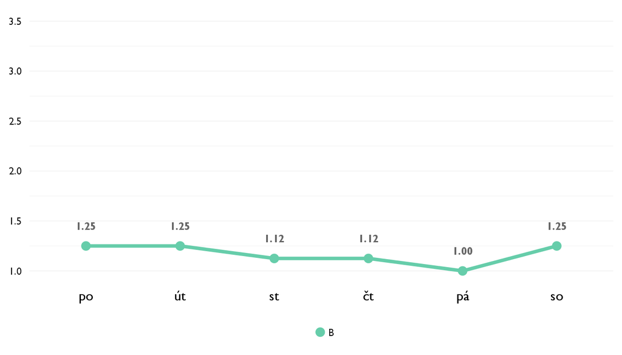

### Co se na kurzu líbilo

- časť o orgánoch
- Uvodni hodina etiky, protoze to bylo hodne prinosne pro vsechny budouci diskuze + se mi libily skvele pripravene materialy, ze kterych jsem sice stihla jenom malou cast pred discoverem, ale urcite se k nim vratim.
- Jednoznacne sa mi pacil vyber tem, o ktorych sme diskutovali a sposob, ktorym Alex viedla hodiny. Bolo super, ze nam najprv poskytla fakty a vysvetlila ako jednotlive problemy funguju, potom bolo na nas aby sme diskutovali a vytvorili si nazor k jednotlivym temam. Pacilo sa mi, ze chcela aby sme argumentovali svoje nazory.
- Pacilo sa mi ako sme mohli diskutovat o danej teme a pacili sa mi nase prestavky.
- Možnost vyjádřit ve ke všem zajímavým tématům a prodiskutovat je. Příjemná lektrka, dobré rostředí, možnost se vyjádřit.
- Nejvice se mi libila umela reprodukce, protoze jsem se nad tim hodne do hloubky zamyslela
- Naše milá lektorka
- Všetko :). Diskusie a aj teoria boli veľmi vybalancované.

### Co na kurzu změnit

- viac štatistík a informácii
- Nic bych nemenila, kurz byl super!
- Mohli by sme riesit viac realnych pripadov.
- Mne sa tento workshop velmi pacil a nemenila by som nic.
- Vše bylo super. Možná mě méně zaujala sobotí hodina společně s kurzem medicíny.
- Nic
- Více zspojit teoretické znalosti
- nic.

## Hodnocení lektora

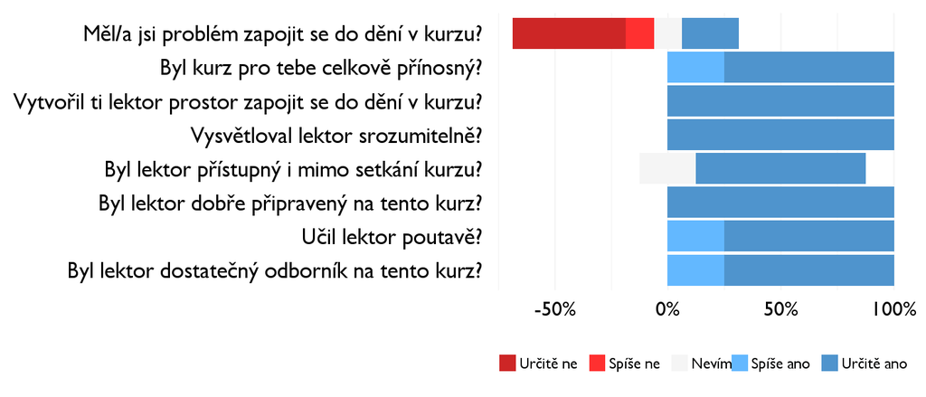

### Komentáře k lektorovi

- ďakujeme za cukríky!
- Alex!! Cukříky nas motivovali!

## Náročnost kurzu

### **Jak hodnotíš náročnost…**

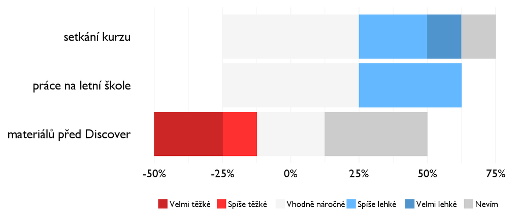

## Didaktika

Na některé otázky jsme se na augustovém turnuse neptali - tam uvidíte nadpis bez grafu.

### Jak lektor učí a měl by to změnit?

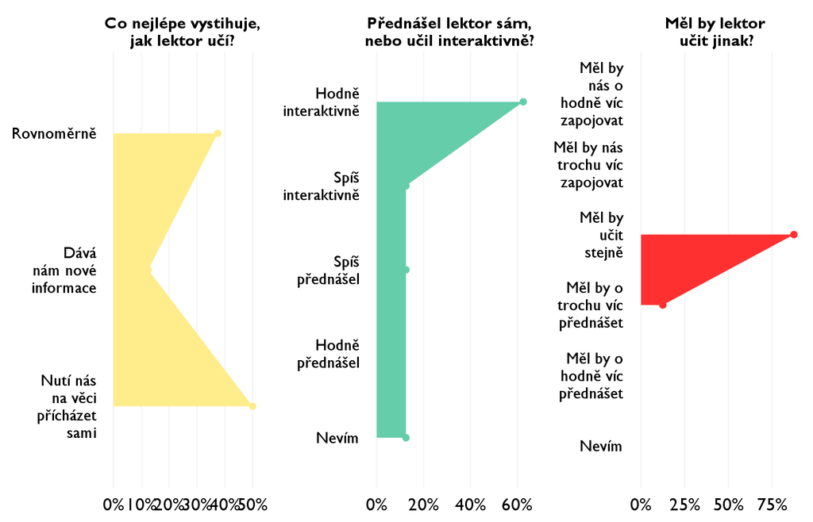

### Jak se studentům nejlépe učí?

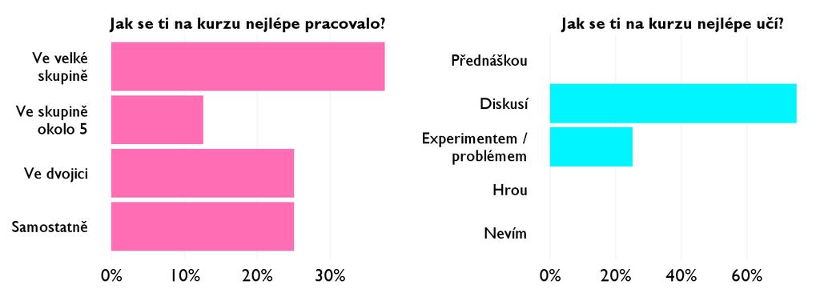

## Ovlivnil tě kurz nějak?

**Pokud ano, jak? Pokud ne, proč ne?**

- zamyslenie sa nad vecammi
- Zaujala me hodina o genech, takze se budu snazit se o nich neco dozvedet i z biologickeho hlediska
- Naucila som sa chapat, preco maju ludia ine nazory ako ja a co ich viedlo k tomu, aby si taketo nazory vytvorili. Taktiez, Alex nam ukazala, ze treba zvazovat vela faktorov suvisiacich s jednotlivým problemom na ktore som predtym zabudala alebo ich uplne odignorovala.
- Pomohol mi zistit ake maju ludia nazory naprikr nnahradne materstvo.
- Donutil mě hlouběji se zamyslet nad etickými otázkami. Dívat se ně z různých pohledů.
- Zamysleni nad zivotnimi situacemi
- Bud se ještě více bát pokroků v genetice
- Rozmýšlať o otázkach etiky vždy niečo vo vás zmení, ani kurz bioetiky nebol iný.